# **Facteurs influençants la prise des transports en commun pour l’agglomération grenobloise**

RACHDI Mustapha - SAUNIER Florent - SAADALLAH Malek

Janvier 2024

# Préambule

Ce projet se base sur des données récoltées par l’ENQUÊTE MÉNAGES DÉPLACEMENTS en 2010 dans la région Grenobloise. L’étude a pour but de déterminer les facteurs influençant la prise des transports en commun . Pour cela nous nous sommes pris comme limites : le réseau Mtag qui comprend les bus qualifiés de “ville” (Nous n’avons pas pris en compte les bus régionaux comme par exemple le bus Grenoble - Chamrousse) et le réseau du tramway dont les lignes depuis 2010 ont été augmentées.

## 1. Objectif

Déterminer les facteurs influençant la prise des transports en commun pour l’agglomération grenobloise : Etudier l’impact des variables socio-économiques.

## 3. Résultats

Les facteurs qui favorisent l’utilisation des transports en commun :

- Être étudiant

Les facteurs qui défavorisent l’utilisation des transports en commun :

- Faire partie d’une catégorie socio-professionnelle aisée

# Préparation de la base de données

## Etat de l’art

L’état de l’art relatif aux facteurs influençant l’utilisation des transports en commun urbains, tel que synthétisé à partir des travaux de Paulley et al. (2006), Redman et al. (2013), Zhang et al. (2022), Rasca & Saeed (2022), et Göransson & Andersson (2023), révèle une diversité de variables interdépendantes, classifiables en plusieurs catégories principales :

1. **Facteurs Économiques et Sociaux** : Les caractéristiques socio-économiques individuelles comme le revenu, la possession d’un permis de conduire, et l’accès à une voiture sont essentielles. (Paulley et al. 2006) ont notamment mis en évidence l’impact de ces facteurs sur la demande de transport en commun.
2. **Caractéristiques des Services de Transport** : Les attributs tels que les tarifs, la qualité du service, et le confort sont cruciaux (Redman et al., 2013). La perception de ces éléments peut significativement influencer les choix de mobilité.
3. **Facteurs Spatiaux** : La taille du ménage et les caractéristiques spatiales des lieux de résidence et de destination, comme la densité, influent sur l’usage des transports en commun (Zhang et al., 2022).
4. **Motivations et Perceptions** : Les motivations instrumentales, affectives, et symboliques, ainsi que les politiques publiques et les expériences émotionnelles liées à l’utilisation des transports en commun, peuvent encourager leur utilisation (Göransson & Andersson, 2023).
5. **Considérations Environnementales** : L’attrait pour des modes de transport plus durables, sous l’effet de la prise de conscience des enjeux environnementaux, peut également jouer un rôle (Rasca & Saeed, 2022).

## Overview de la base de données

```r
load("allgre.PB_V2.RData")

DB_projet_full <- allgre.PB_V2

n_rows <- nrow(DB_projet_full)
n_cols <- ncol(DB_projet_full)

n_personnes <- nrow(table(DB_projet_full$id_pers))
n_trips <- nrow(table(DB_projet_full$id_depl))
n_mng <- nrow(table(DB_projet_full$id_men))

n_missing <- sum(is.na(DB_projet_full))

n_cols_without_na <- ncol(DB_projet_full[!apply(DB_projet_full, 2, anyNA)])

cat("Nombre d'observations :", n_rows, "\n")
```

```
## Nombre d'observations : 30702
```

```r
cat("Nombre de variables :", n_cols, "\n")
```

```
## Nombre de variables : 116
```

```r
cat("Nombre de personnes :", n_personnes, "\n")
```

```
## Nombre de personnes : 7766
```

```r
cat("Nombre de trajets :", n_trips, "\n")
```

```
## Nombre de trajets : 27890
```

```r
cat("Nombre de ménages :", n_mng, "\n")
```

```
## Nombre de ménages : 3236
```

```r
cat("Nombre de valeurs manquantes :", n_missing, "\n")
```

```
## Nombre de valeurs manquantes : 971658
```

```r
cat("Proportion de valeurs manquantes :", round(n_missing/(n_rows * n_cols), 4)*100, "% \n")
```

```
## Proportion de valeurs manquantes : 27.28 %
```

```r
cat("Proportion de variables sans valeurs manquantes :", round(n_cols_without_na/n_cols, 4)*100, "% \n")
```

```
## Proportion de variables sans valeurs manquantes : 20.69 %
```

Cependant, on peut établir quelques critères avec r : ration de valeurs manquantes dans la colonne.

- Bon : $r \leq 5\%$
- Moyen :$5\% < r \leq 20\%$
- Mauvais : $20\% < r \leq 45\%$
- Très mauvais : $r > 45%$

Plusieurs variables ont entre 80% et 99% de valeurs manquantes. Ceci est dû au fait que la plupart de gens n’ont tout simplement pas plus d’un véhicule, ce qui fait que les variables correspondantes sont vides.

## Variables

### Variables de base

```r
DB_projet_full$freqtcu2<-DB_projet_full$freqtcu
 DB_projet_full<-DB_projet_full%>%mutate(freqtcu=ifelse(freqtcu<=3,1,0))
DB_projet_full$freqtcu<-factor(DB_projet_full$freqtcu)
```

**Frecqtcu** : Variable d’intérêt (Y) catégorielle qui indique la fréquence d’utilisation des transports en communs chez une personne.

Elle prend les valeurs :

**1 :** Utilisation des transports en commun **tous les jours**

**2 :** Utilisation des transports en commun **au moins deux fois par semaine**

**3 :** Utilisation des transports en commun **au moins deux fois par mois**

**4 :** Utilisation des transports en commun **très rare**

**5 :** Utilisation des transports en commun **inexistante**

Nous avons décidé de construire *frecqtcu* de manière à ce qu’elle soit binaire. Pour toutes les personnes qui prennent les transports de manière : régulière/tous les jours , au moins deux fois par semaine et au moins deux fois par mois se sont vues attribuées la valeur 1 car le “au moins” présage une prise des transports en communs plus élevée.

**Tailmng** : Variable qui indique le nombre de personnes composant le ménage.

```r
DB_projet_full<-rename(DB_projet_full,"tailmng"="NO_PERS")
```

On change simplement le nom de la variable “NO_PERS” qui indique le nombre de personne dans le ménage **Permis** :Variable indiquant si la personne effectuant le trajet possède le permis ou pas.

```r
DB_projet_full<-DB_projet_full%>%mutate(permis=ifelse(any(permis==1 | permis==3),"YES","NO"))
DB_projet_full$permis<-factor(DB_projet_full$permis)
```

**Car_ownership** : Variable indiquant si la personne effectuant le trajet possède une voiture pour ses déplacements

```r
#DB_projet_full<-DB_projet_full%>%mutate(car_ownership=ifelse(DB_projet_full$VP_DISPO>0 & (DB_projet_full$GENRE1!=2 | #DB_projet_full$GENRE2!=2 | DB_projet_full$GENRE3!=2 | DB_projet_full$GENRE4!=2) & (DB_projet_full$POSSES1==1 | #DB_projet_full$POSSES2==1 | DB_projet_full$POSSES3==1 | DB_projet_full$POSSES4==1),"OUI","NON"))

#DB_projet_full$car_ownership<-factor(DB_projet_full$car_ownership)

DB_projet_full<-DB_projet_full%>%mutate(car_ownership=ifelse(DB_projet_full$dispovp==1 | DB_projet_full$dispovp==2,"OUI","NON"))
DB_projet_full$car_ownership<-factor(DB_projet_full$car_ownership)

#table(DB_reduced$car_ownership_2)
```

### Variables complémentaires

Grâce aux variables précédentes et aux articles que l’on a trouvé dans la littérature, nous allons construire notre base de données pour notre modèle. Nous exploiterons un ensemble de caractéristiques socio-économiques puis certaines variables liées au “confort” du trajet.

```r
# Variables liées au confort
Variables_supp<-c(1,2,6,7,8,20,21,47,49,53,54,55,56,57,59,60,61,62,63,76,87,88,89,91,102,107,108,109,112,113,115,117) #c'est là qu'on va ajouter nos variables
#str(DB_reduced[,Variables_supp])

New_DB<-cbind(DB_projet_full[,Variables_supp],DB_projet_full$freqtcu,DB_projet_full$permis,DB_projet_full$tailmng,DB_projet_full$car_ownership) #création de la nouvelles bases de données

New_DB<-rename(New_DB,"freqtcu"="DB_projet_full$freqtcu")
New_DB<-rename(New_DB,"permis"="DB_projet_full$permis")
New_DB<-rename(New_DB,"tailmng"="DB_projet_full$tailmng")
New_DB<-rename(New_DB,"car_ownership"="DB_projet_full$car_ownership")
New_DB<-rename(New_DB,"PBM_STAT_GENERAL"="PBM_STAT")
```

Cette base de données va regrouper toutes les variables nécessaires à notre étude puis on la redivisera encore par la suite pour notamment l’utilisation de cluster

```r
New_DB$TYPE_HAB<-replace(New_DB$TYPE_HAB,New_DB$TYPE_HAB==1,"INDIVIDUEL_ISO")
New_DB$TYPE_HAB<-replace(New_DB$TYPE_HAB,New_DB$TYPE_HAB==2,"INDIVIDUEL_COLE")
New_DB$TYPE_HAB<-replace(New_DB$TYPE_HAB,New_DB$TYPE_HAB==3,"PETIT_COLLECTIF")
New_DB$TYPE_HAB<-replace(New_DB$TYPE_HAB,New_DB$TYPE_HAB==4,"GRAND_COLLECTIF")
New_DB$TYPE_HAB<-replace(New_DB$TYPE_HAB,New_DB$TYPE_HAB==5,"AUTRE")
New_DB$TYPE_HAB<-factor(New_DB$TYPE_HAB)


New_DB$TYPE_OCU<-replace(New_DB$TYPE_OCU,New_DB$TYPE_OCU==1,"PROPRIETAIRE")
New_DB$TYPE_OCU<-replace(New_DB$TYPE_OCU,New_DB$TYPE_OCU==2,"LOCATAIRE_HLM")
New_DB$TYPE_OCU<-replace(New_DB$TYPE_OCU,New_DB$TYPE_OCU==3,"AUTRE_LOCATAIRE")
New_DB$TYPE_OCU<-replace(New_DB$TYPE_OCU,New_DB$TYPE_OCU==4,"LOGE_GRATUIT")
New_DB$TYPE_OCU<-replace(New_DB$TYPE_OCU,New_DB$TYPE_OCU==5,"AUTRE")
New_DB$TYPE_OCU<-factor(New_DB$TYPE_OCU)

New_DB$jourdepl<-replace(New_DB$jourdepl,New_DB$jourdepl==1,"LUNDI")
New_DB$jourdepl<-replace(New_DB$jourdepl,New_DB$jourdepl==2,"MARDI")
New_DB$jourdepl<-replace(New_DB$jourdepl,New_DB$jourdepl==3,"MERCREDI")
New_DB$jourdepl<-replace(New_DB$jourdepl,New_DB$jourdepl==4,"JEUDI")
New_DB$jourdepl<-replace(New_DB$jourdepl,New_DB$jourdepl==5,"VENDREDI")
New_DB$jourdepl<-factor(New_DB$jourdepl)






New_DB<-New_DB%>%mutate(LIEU_STAT1=ifelse(is.na(LIEU_STAT1),0,LIEU_STAT1))
New_DB$LIEU_STAT1<-replace(New_DB$LIEU_STAT1,New_DB$LIEU_STAT1==1,"GARAGE/BOX")
New_DB$LIEU_STAT1<-replace(New_DB$LIEU_STAT1,New_DB$LIEU_STAT1==2,"RUE")
New_DB$LIEU_STAT1<-replace(New_DB$LIEU_STAT1,New_DB$LIEU_STAT1==3,"PARKING PUBLIC")
New_DB$LIEU_STAT1<-replace(New_DB$LIEU_STAT1,New_DB$LIEU_STAT1==4,"PARKING PRIVÉ")
New_DB$LIEU_STAT1<-replace(New_DB$LIEU_STAT1,New_DB$LIEU_STAT1==0,"PAS_INFO") #traitement des valeurs manquantes
New_DB$LIEU_STAT1<-factor(New_DB$LIEU_STAT1)

New_DB<-New_DB%>%mutate(TYPE_STAT1=ifelse(is.na(TYPE_STAT1),0,TYPE_STAT1))
New_DB$TYPE_STAT1<-replace(New_DB$TYPE_STAT1,New_DB$TYPE_STAT1==1,"INTERDIT")
New_DB$TYPE_STAT1<-replace(New_DB$TYPE_STAT1,New_DB$TYPE_STAT1==2,"GRATUIT")
New_DB$TYPE_STAT1<-replace(New_DB$TYPE_STAT1,New_DB$TYPE_STAT1==3,"PAYANT")
New_DB$TYPE_STAT1<-replace(New_DB$TYPE_STAT1,New_DB$TYPE_STAT1==4,"PAYÉ_TIERCE")
New_DB$TYPE_STAT1<-replace(New_DB$TYPE_STAT1,New_DB$TYPE_STAT1==0,"PAS_INFO") #traitement des valeurs manquantes on aura besoin de ça après
New_DB$TYPE_STAT1<-factor(New_DB$TYPE_STAT1)

New_DB$sexe<-replace(New_DB$sexe,New_DB$sexe==1,"Homme")
New_DB$sexe<-replace(New_DB$sexe,New_DB$sexe==2,"Femme")
New_DB$sexe<-factor(New_DB$sexe)

New_DB$etabscol<-replace(New_DB$etabscol,New_DB$etabscol==2,"CAP")
New_DB$etabscol<-replace(New_DB$etabscol,New_DB$etabscol==3,"BEP")
New_DB$etabscol<-replace(New_DB$etabscol,New_DB$etabscol==4,"BAC")
New_DB$etabscol<-replace(New_DB$etabscol,New_DB$etabscol==5,"BAC+2")
New_DB$etabscol<-replace(New_DB$etabscol,New_DB$etabscol==6,"BAC >= 3")
New_DB$etabscol<-replace(New_DB$etabscol,New_DB$etabscol==7,"APPRENTISSAGE")
New_DB$etabscol<-replace(New_DB$etabscol,New_DB$etabscol==1,"PAS DIPLOME")
New_DB$etabscol<-factor(New_DB$etabscol)











New_DB$OCCU1 <- replace(New_DB$OCCU1, New_DB$OCCU1 == 1, "TravaiPleinT")
New_DB$OCCU1 <- replace(New_DB$OCCU1, New_DB$OCCU1 == 2, "TravailPartT")
New_DB$OCCU1 <- replace(New_DB$OCCU1, New_DB$OCCU1 == 3, "Appreti_Stage")
New_DB$OCCU1 <- replace(New_DB$OCCU1, New_DB$OCCU1 == 4, "Etudiant")
New_DB$OCCU1 <- replace(New_DB$OCCU1, New_DB$OCCU1 == 7, "Retraite")
New_DB$OCCU1 <- replace(New_DB$OCCU1, New_DB$OCCU1 == 5, "Scolaire")
New_DB$OCCU1 <- replace(New_DB$OCCU1, New_DB$OCCU1 == 6, "RSA")
New_DB$OCCU1 <- replace(New_DB$OCCU1, New_DB$OCCU1 == 8, "Reste_auFoyer")
New_DB$OCCU1 <- replace(New_DB$OCCU1, New_DB$OCCU1 == 9, "Autre")
New_DB$OCCU1=factor(New_DB$OCCU1)

New_DB$OCCU2 <- replace(New_DB$OCCU2, New_DB$OCCU2 == 0, "NON_Con")
New_DB$OCCU2 <- replace(New_DB$OCCU2, New_DB$OCCU2 == 1, "Travail")
New_DB$OCCU2 <- replace(New_DB$OCCU2, New_DB$OCCU2 == 2, "Etudes")
New_DB$OCCU2=factor(New_DB$OCCU2)

New_DB$csp<-replace(New_DB$csp,New_DB$csp==21 | New_DB$csp==22 | New_DB$csp==23 |New_DB$csp==31 | New_DB$csp==32 | New_DB$csp==36 | New_DB$csp==41 | New_DB$csp==46 | New_DB$csp==51 | New_DB$csp==54 | New_DB$csp==55,"HIGH_STATUT")
New_DB$csp<-replace(New_DB$csp,New_DB$csp==10 | New_DB$csp==47 | New_DB$csp==48 |New_DB$csp==56 | New_DB$csp==61| New_DB$csp==66 | New_DB$csp==69 |New_DB$csp==81 | New_DB$csp==82 | New_DB$csp==90,"LOW_STATUT")
New_DB$csp<-replace(New_DB$csp,New_DB$csp==83 | New_DB$csp==84 | New_DB$csp==85 | New_DB$csp==86 | New_DB$csp==87 | New_DB$csp==99 , "ETUDES")
New_DB$csp<-factor(New_DB$csp)

New_DB<-New_DB%>%mutate(ABO_TC=ifelse(is.na(ABO_TC),0,ABO_TC))
New_DB$ABO_TC<-replace(New_DB$ABO_TC,New_DB$ABO_TC==1,"OUI_GRATUIT")
New_DB$ABO_TC<-replace(New_DB$ABO_TC,New_DB$ABO_TC==2,"OUI_PAYANT")
New_DB$ABO_TC<-replace(New_DB$ABO_TC,New_DB$ABO_TC==3,"NON")
New_DB$ABO_TC<-replace(New_DB$ABO_TC,New_DB$ABO_TC==0,"PAS_INFO")
New_DB$ABO_TC<-factor(New_DB$ABO_TC)

New_DB<-New_DB%>%mutate(travdom=ifelse(is.na(travdom),0,travdom))
New_DB$travdom<-replace(New_DB$travdom,New_DB$travdom==1,"OUI")
New_DB$travdom<-replace(New_DB$travdom,New_DB$travdom==2,"NON")
New_DB$travdom<-replace(New_DB$travdom,New_DB$travdom==0,"PAS_INFO")
New_DB$travdom<-factor(New_DB$travdom)


New_DB<-New_DB%>%mutate(zonetrav=ifelse(is.na(zonetrav),0,zonetrav))
New_DB$zonetrav<-replace(New_DB$zonetrav,New_DB$zonetrav==0,"PAS_INFO")
#New_DB<-New_DB%>%mutate(zonetrav=case_when(zonetrav %in% c(100,114)~"CENTRE VILLE"))
New_DB$zonetrav<-replace(New_DB$zonetrav,New_DB$zonetrav %in% c(101001:114009),"CENTRE_VILLE")
New_DB$zonetrav<-replace(New_DB$zonetrav,New_DB$zonetrav %in% c(115001:143009),"AGGLO_PROCHE")
New_DB$zonetrav<-replace(New_DB$zonetrav,New_DB$zonetrav %in% c(201001:9039999),"HORS_GRENOBLE")
New_DB$zonetrav<-factor(New_DB$zonetrav)


New_DB<-New_DB%>%mutate(dispovp=ifelse(is.na(dispovp),0,dispovp))
New_DB$dispovp<-replace(New_DB$dispovp,New_DB$dispovp==1,"OUI UTILISE")
New_DB$dispovp<-replace(New_DB$dispovp,New_DB$dispovp==2,"OUI UTILISE PAS")
New_DB$dispovp<-replace(New_DB$dispovp,New_DB$dispovp==3,"NON")
New_DB$dispovp<-replace(New_DB$dispovp,New_DB$dispovp==0,"PAS INFO")
New_DB$dispovp<-factor(New_DB$dispovp)




New_DB<-New_DB%>%mutate(PBM_STAT_GENERAL=ifelse(is.na(PBM_STAT_GENERAL),0,PBM_STAT_GENERAL))
New_DB$PBM_STAT_GENERAL<-replace(New_DB$PBM_STAT_GENERAL,New_DB$PBM_STAT_GENERAL==1,"OUI")
New_DB$PBM_STAT_GENERAL<-replace(New_DB$PBM_STAT_GENERAL,New_DB$PBM_STAT_GENERAL==2,"NON PLACE RES")
New_DB$PBM_STAT_GENERAL<-replace(New_DB$PBM_STAT_GENERAL,New_DB$PBM_STAT_GENERAL==3,"NON PLACE AUTOUR")
New_DB$PBM_STAT_GENERAL<-replace(New_DB$PBM_STAT_GENERAL,New_DB$PBM_STAT_GENERAL==4,"NON HORAIRES")


New_DB$PBM_STAT_GENERAL<-replace(New_DB$PBM_STAT_GENERAL,New_DB$PBM_STAT_GENERAL==0,"PAS_INFO")
New_DB$PBM_STAT_GENERAL<-factor(New_DB$PBM_STAT_GENERAL)

New_DB<-New_DB%>%mutate(STAT_TRAV=ifelse(is.na(STAT_TRAV),0,STAT_TRAV))
New_DB$STAT_TRAV<-replace(New_DB$STAT_TRAV,New_DB$STAT_TRAV==1,"OUI")
New_DB$STAT_TRAV<-replace(New_DB$STAT_TRAV,New_DB$STAT_TRAV==2,"NON PLACE RES")
New_DB$STAT_TRAV<-replace(New_DB$STAT_TRAV,New_DB$STAT_TRAV==3,"NON PLACE AUTOUR")

New_DB$STAT_TRAV<-replace(New_DB$STAT_TRAV,New_DB$STAT_TRAV==0,"PAS_INFO")
New_DB$STAT_TRAV<-factor(New_DB$STAT_TRAV)


New_DB$motifor<-replace(New_DB$motifor,New_DB$motifor %in% c(22:29),"ETUDES")
New_DB$motifor<-replace(New_DB$motifor,New_DB$motifor %in% c(1:2),"DOMICILE")
New_DB$motifor<-replace(New_DB$motifor,New_DB$motifor %in% c(11:12),"TRAVAIL")
New_DB$motifor<-replace(New_DB$motifor,New_DB$motifor==21,"CRECHE")
New_DB$motifor<-replace(New_DB$motifor,New_DB$motifor %in% c(31:34),"SHOOPING")
New_DB$motifor<-replace(New_DB$motifor,New_DB$motifor %in% c(41:43),"ADMINISTRATIF")
New_DB$motifor<-replace(New_DB$motifor,New_DB$motifor %in% c(51:54),"LOISIRS")
New_DB$motifor<-replace(New_DB$motifor,New_DB$motifor %in% c(61:74),"AMENER/RECHERCHER QLQN")
New_DB$motifor<-replace(New_DB$motifor,New_DB$motifor %in% c(81:99),"AUTRES")
New_DB$motifor<-factor(New_DB$motifor)

New_DB<-New_DB%>%mutate(prisecharge=ifelse(is.na(prisecharge),0,prisecharge))
New_DB$prisecharge<-replace(New_DB$prisecharge,New_DB$prisecharge>=1,"NON")
New_DB$prisecharge<-replace(New_DB$prisecharge,New_DB$prisecharge==3,"NON")
New_DB$prisecharge<-replace(New_DB$prisecharge,New_DB$prisecharge==0,"PAS_INFO")
New_DB$prisecharge<-factor(New_DB$prisecharge)

New_DB<-New_DB%>%mutate(NAT_STAT=ifelse(is.na(NAT_STAT),0,NAT_STAT))
New_DB$NAT_STAT<-replace(New_DB$NAT_STAT,New_DB$NAT_STAT==1,"INTERDIT")
New_DB$NAT_STAT<-replace(New_DB$NAT_STAT,New_DB$NAT_STAT==2,"GRATUIT")
New_DB$NAT_STAT<-replace(New_DB$NAT_STAT,New_DB$NAT_STAT==3,"PAYANT")
New_DB$NAT_STAT<-replace(New_DB$NAT_STAT,New_DB$NAT_STAT==4,"PAYE_TIERCE")
New_DB$NAT_STAT<-replace(New_DB$NAT_STAT,New_DB$NAT_STAT==0,"PAS_INFO")
New_DB$NAT_STAT<-factor(New_DB$NAT_STAT) # on transofmre les données qualitiatives en vecteurs ce qui permet par la suite de faire des clustering par exemple.
```

## Restriction géographique

Définissons ce que l’on entend par “transports en communs”.

Pour notre étude nous nous concentrons sur les transports en communs de la société M-Tag,c’est à dire les tram et bus du réseau.

Notre délimitation géographique sera simplement les terminaux des différentes lignes de tram/bus confondues.

Par la suite, quand on parlera de transports en communs, on se refère à la définition au dessus.

[figure not shown]

```r
knitr::include_graphics("reseau tag.jpg", )
```

```r
Vec_zone<-c(101,102,103,104,105,106,107,108,109,110,111,112,113,114,117,118,135,119,120,136,121,122,123,124,125,126,137,138,127,128,129,130,131,132,115,140,116,134,141,142,143,302)
```

```r
New_DB<-dplyr::filter(New_DB,tir %in% Vec_zone) #on garde que les zones où il y a des transports en communs
```

# Analyse

## Impact de l’occupation

Pour commencer, nous allons étudier l’impact de l’occupation sur l’utilisation des transports en commun.

```r
DB_cat_soc <- New_DB[!duplicated(New_DB$id_pers),]

DB_cat_soc <- DB_cat_soc %>% select(id_pers, freqtcu, OCCU1) %>% na.omit() %>% dplyr::mutate(OCCU1 = as.factor(OCCU1))
```

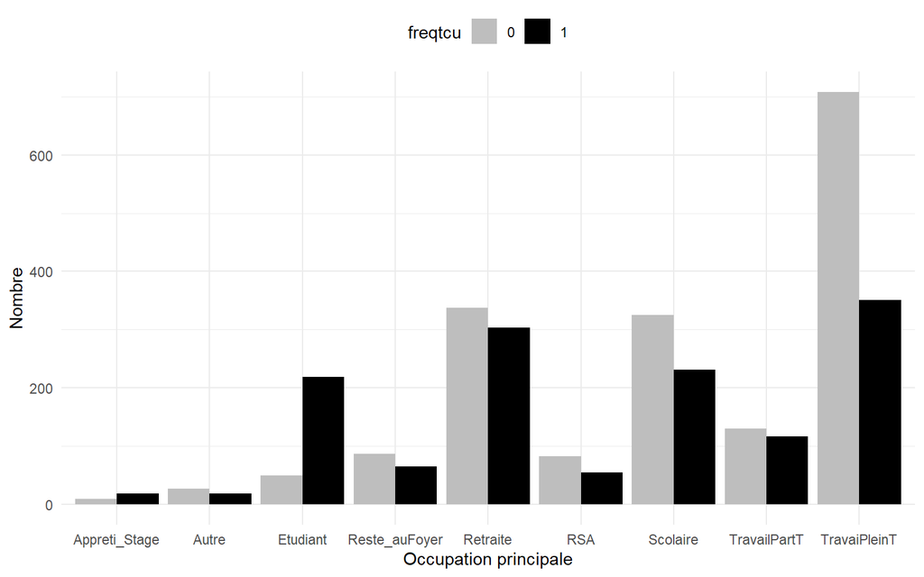

```r
# Plotting
ggplot(DB_cat_soc, aes(x = OCCU1, fill = as.factor(freqtcu))) +
  geom_bar(position = "dodge", stat = "count") +
  scale_fill_manual(values = c("0" = "grey", "1" = "black")) +
  labs(x = "Occupation principale", y = "Nombre", fill = "freqtcu") +
  theme_minimal() +
  theme(legend.position = "top")
```

Nous remarquons que les étudiants utilisent majoritairement les transports en commun.

```r
Etu <- DB_cat_soc %>% filter(OCCU1 == "Etudiant") %>% count(freqtcu)
Etu_use <- Etu %>% filter(freqtcu == 1) %>% select(n)


perc_Etu_use <- Etu_use/nrow(DB_cat_soc %>% filter(OCCU1 == "Etudiant") %>% na.omit())
perc_Etu_use <- as.numeric(perc_Etu_use)
cat("Proportion d'étudiants utilisant les transports en commun :", round(perc_Etu_use, 4)*100, "% \n")
```

```
## Proportion d'étudiants utilisant les transports en commun : 81.41 %
```

81% des étudiants utilisent les transports en commun. Nous allons donc, nous intéresser aux non étudiants.

## Etude des non étudiants

```r
#Base donnée catégorie socio prof personnes

DB_pers_socio_1<-New_DB[,c(1,8,9,10,11,12,13,14,15,16,26,32,33,34,35,36)]
DB_pers_socio_1<-DB_pers_socio_1[!duplicated(DB_pers_socio_1$id_pers),]
DB_pers_socio_1<-dplyr::filter(DB_pers_socio_1,!is.na(DB_pers_socio_1$freqtcu))
DB_pers_socio_1<-dplyr::filter(DB_pers_socio_1,!is.na(DB_pers_socio_1$car_ownership))

DB_pers_socio_1<-dplyr::filter(DB_pers_socio_1,DB_pers_socio_1$zonetrav!="PAS_INFO")
#vis_miss(DB_pers_socio_1) # un peu freqtcu manquant 1% on peut l'enlever
```

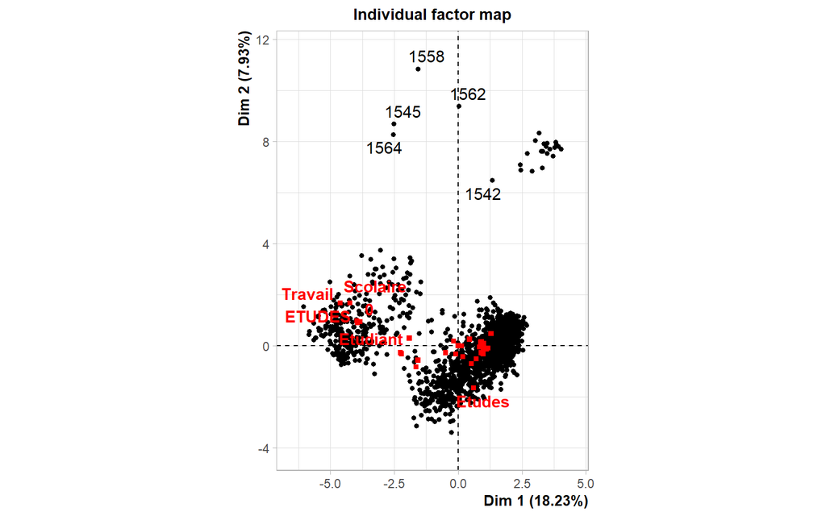

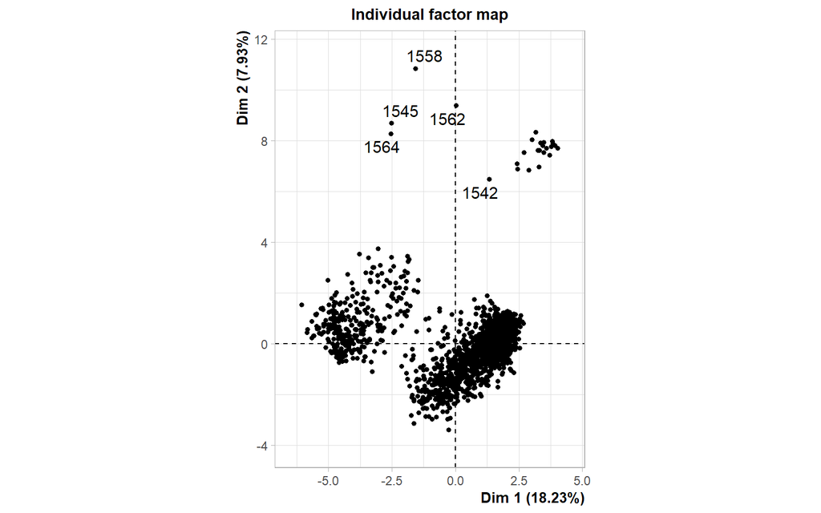

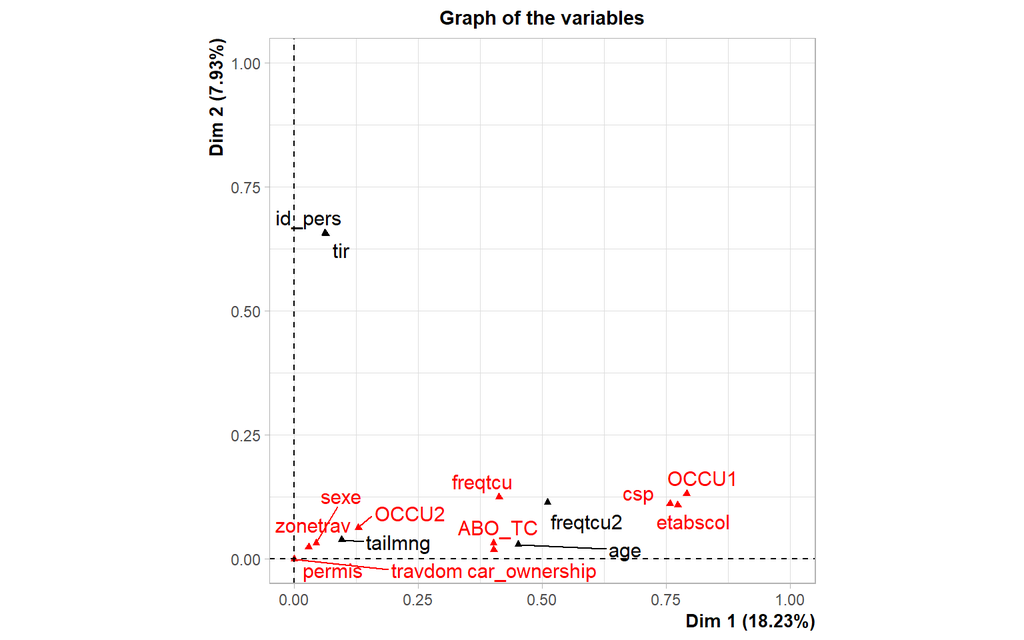

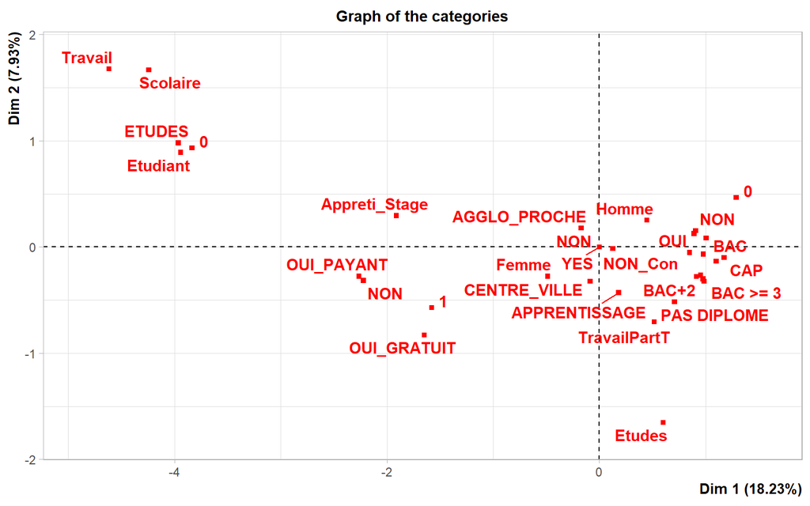

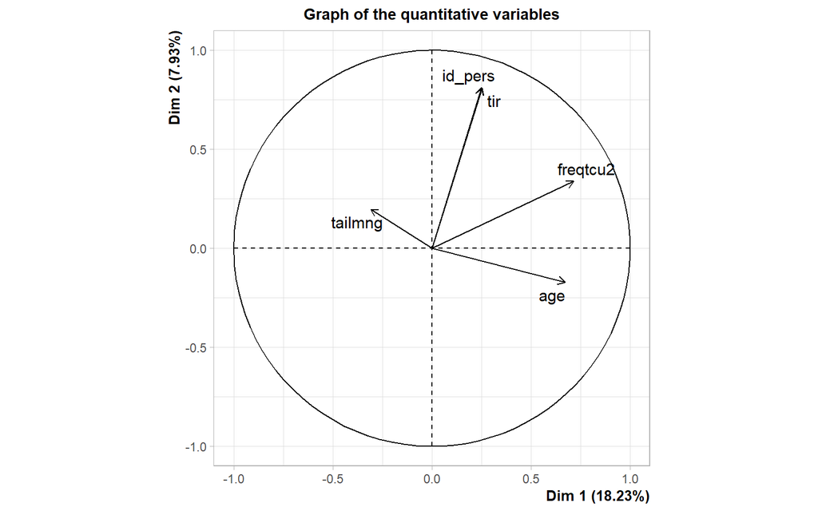

```r
#DB_cluster_2<-DB_cluster_1[sample(c(TRUE,FALSE),size=nrow(DB_cluster_1),replace=TRUE,prob=c(0.05,0.95)),]
afm_1<-FAMD(base=DB_pers_socio_1,ncp=5)
```

```r
#Affichage des coordonnées 5 variables latentes deux à deux orthogonales
#head(afm_1$ind$coord,10)
```

```r
#Mettre les individus deux à deux si on arrive à distinguer des patterns  des formes

#pairs(afm_1$ind$coord,cex=0.6)

#Trouver les groupes pas évident
```

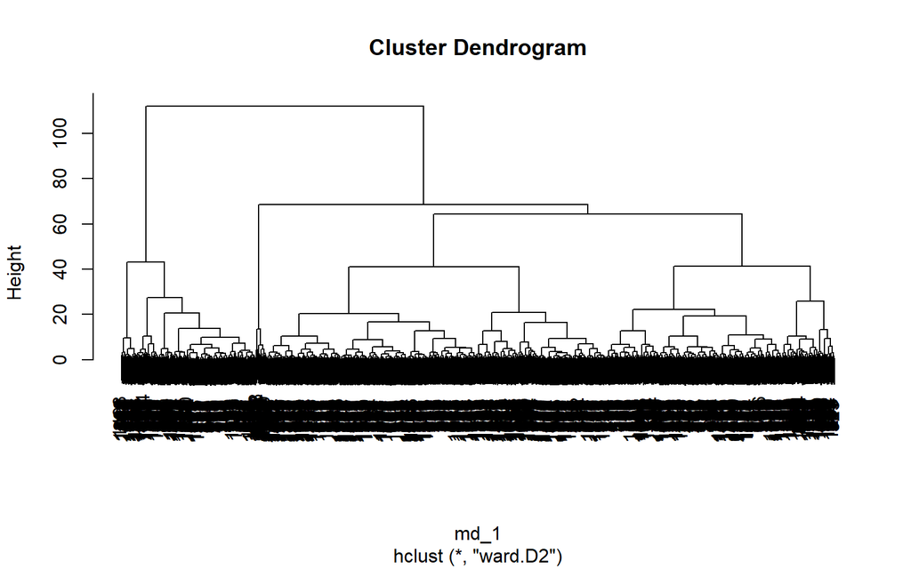

```r
#Classification ascendante hiérarchique
md_1<-dist(afm_1$ind$coord)

ch_1<-hclust(md_1,method='ward.D2')

plot(ch_1)
```

```r
#Le bazar mais c'est normal au vu de tous les individus , le dendograme

#2carts de hauteur entre les paliers , ça donne une idée de la distance entre les clusters , ici deux groupes pas évident , peut être 3 groupes. Ici on tatonne pas comparé aux k-means où il faut tatonner pour trouver le bon nombre de groupe
```

```r
groups_1<-cutree(ch_1,k=3)

#table(groups_1)
```

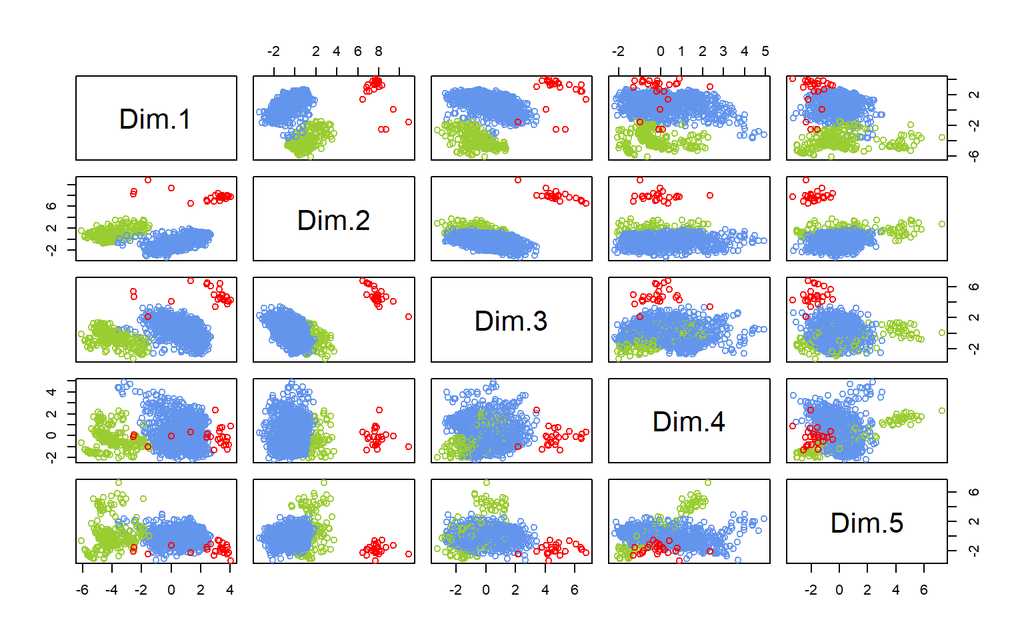

```r
pairs(afm_1$ind$coord,col=c('cornflowerblue','yellowgreen','red')[groups_1],cew=0.75)
```

```r
#sapply(DB_pers_socio_1[sapply(DB_pers_socio_1,is.numeric)],mean)
```

```r
#lapply(DB_pers_socio_1[sapply(DB_pers_socio_1,is.numeric)],function(x){tapply(x,groups_1,mean)})
```

```r
#sapply(DB_pers_socio_1[sapply(DB_pers_socio_1,is.factor)],function(x){prop.table(table(x))})
```

```r
#sapply(DB_pers_socio_1[sapply(DB_pers_socio_1,is.factor)],function(x){prop.table(table(groups_1,x),1)})
```

## Cluster avec Car_ownership

Ici on va restreindre notre base de données avec les déplacements des personnes et l’influence des variables dites de confort reliées à la voiture , car_ownership n’est plus simplement le fait de posséder une voiture c’est plus global que cela

```r
#c(6,7,8,9,17,18,19,20,21,23,24,28,31)
DB_car_ownership<-New_DB[,c(8,9,18,26,33,34,36)]
DB_car_ownership<-DB_car_ownership[!duplicated(DB_car_ownership$id_pers),]
#DB_car_ownership<-dplyr::filter(DB_car_ownership,!is.na(DB_car_ownership$id_depl))
#DB_car_ownership<-dplyr::filter(DB_car_ownership,!is.na(DB_car_ownership$duree))
DB_car_ownership<-dplyr::filter(DB_car_ownership,!is.na(DB_car_ownership$car_ownership))
DB_car_ownership<-dplyr::filter(DB_car_ownership,!is.na(DB_car_ownership$freqtcu))

#DB_car_ownership<-dplyr::filter(DB_car_ownership,DB_car_ownership$PBM_STAT_GENERAL!="PAS_INFO")
#DB_car_ownership<-dplyr::filter(DB_car_ownership,DB_car_ownership$STAT_TRAV!="PAS_INFO")

#vis_miss(DB_car_ownership)
```

```r
#table(DB_car_ownership$car_ownership)
```

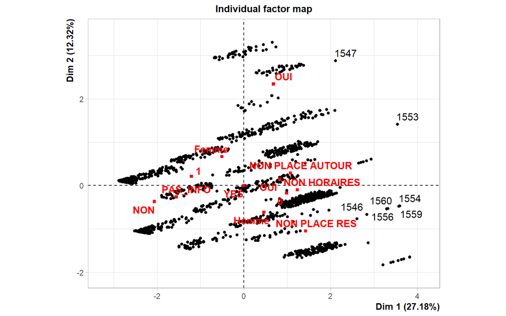

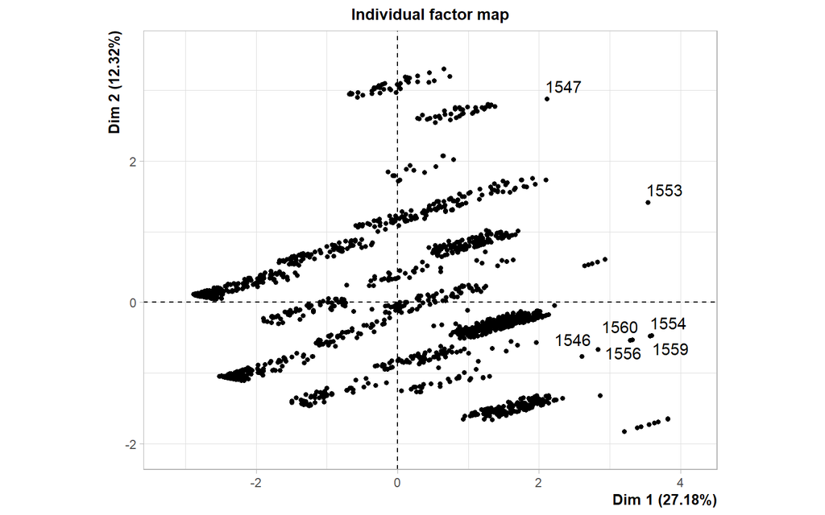

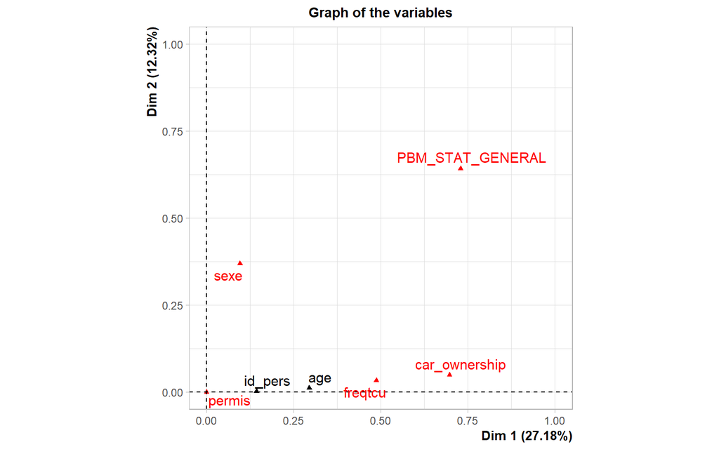

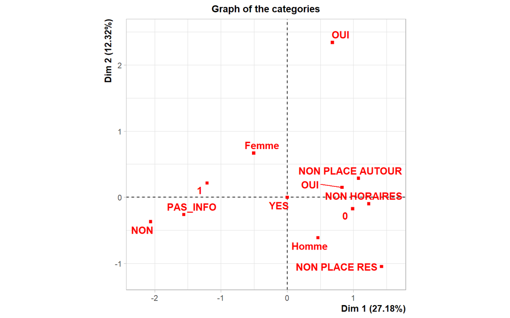

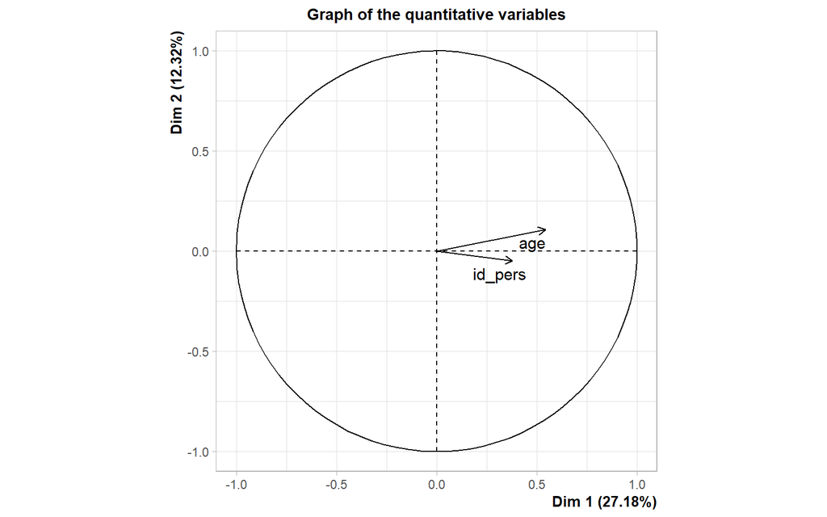

```r
afm_3<-FAMD(DB_car_ownership, ncp=5)
```

```r
#summary(afm_3)
```

```r
#head(afm_3$ind$coord)
```

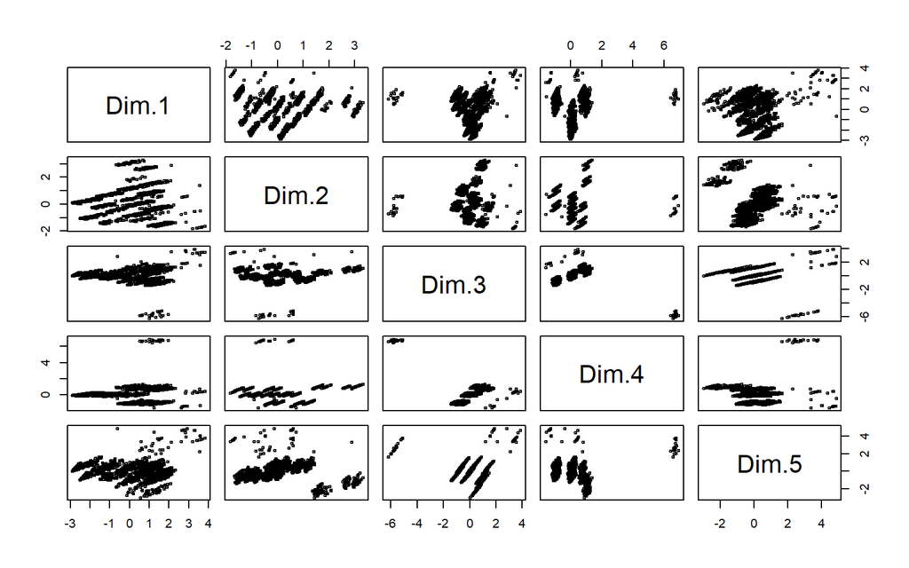

```r
pairs(afm_3$ind$coord,cex=0.5)
```

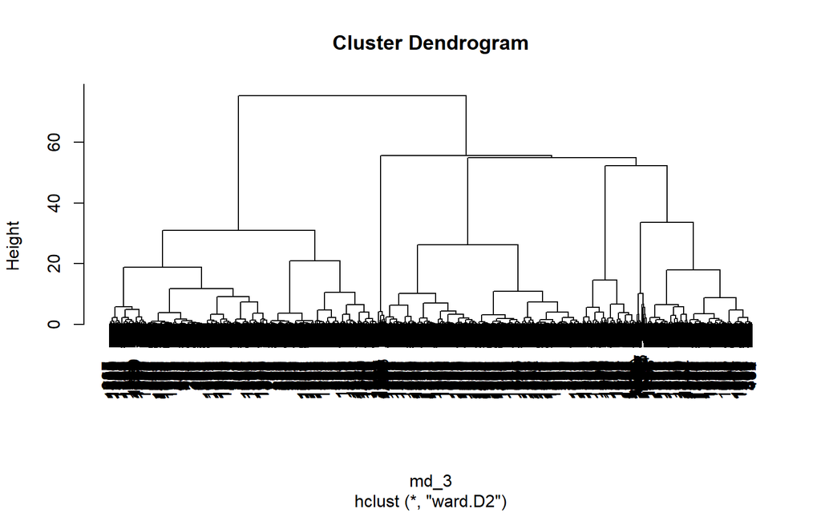

```r
md_3<-dist(afm_3$ind$coord)
ch_3<-hclust(md_3,method="ward.D2")

plot(ch_3)
```

```r
groups_3<-cutree(ch_3,k=3)
#table(groups_3)
```

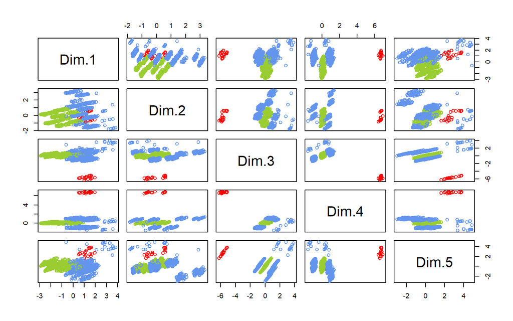

```r
pairs(afm_3$ind$coord,col=c('cornflowerblue','yellowgreen','red')[groups_3],cew=0.75)
```

```r
#lapply(DB_car_ownership[sapply(DB_car_ownership,is.numeric)],function(x){tapply(x,groups_3,sd)})
#lapply(DB_car_ownership[sapply(DB_car_ownership,is.numeric)],function(x){tapply(x,groups_3,mean)})
#lapply(DB_car_ownership[sapply(DB_car_ownership,is.numeric)],function(x){tapply(x,groups_3,var)})
```

```r
#sapply(DB_car_ownership[sapply(DB_car_ownership,is.factor)],function(x){prop.table(table(groups_3,x),1)})
```

Le confort lié à la voiture se traduit par une place de parking disponible ou non une fois arrivé sur son lieu de travail ou d’études,il semblerait que le fait d’avoir une place de parking sur son lieu de travail encourage les gens a prendre leur voiture plutôt que les transports en communs. 66% des personnes du groupe 2 (75% des personnes n’ont pas une utilisation régulière des transports en communs) n’auraient pas de problèmes de stationnement au travail. De plus, le simple fait d’avoir une voiture n’a pas un rôle significatif dans l’utilisation ou non des transports en communs. Il est important de noter qu’il y a beaucoup de valeurs manquantes en ce qui concerne les variables PBM STAT et STAT TRAV

## Cluster avec les trajets

```r
DB_trip<-New_DB[,c(20,21,22,23,26,27,28,29,30,31,33,36)]
DB_trip<-dplyr::filter(DB_trip,!is.na(DB_trip$id_traj))
DB_trip<-dplyr::filter(DB_trip,!is.na(DB_trip$ntraj))
DB_trip<-dplyr::filter(DB_trip,!is.na(DB_trip$Couteff))
DB_trip<-dplyr::filter(DB_trip,!is.na(DB_trip$car_ownership))
#DB_trip<-dplyr::filter(DB_trip,!is.na(DB_trip$D13))



#vis_miss(DB_trip)
```

```r
DB_trip_2<-DB_trip[,-c(5,6,9)]
```

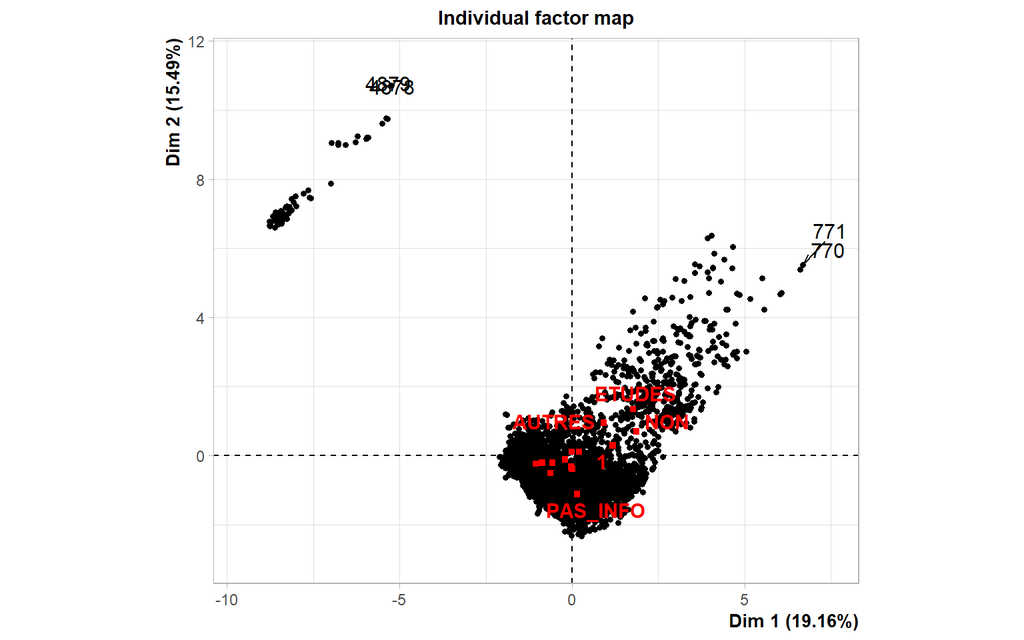

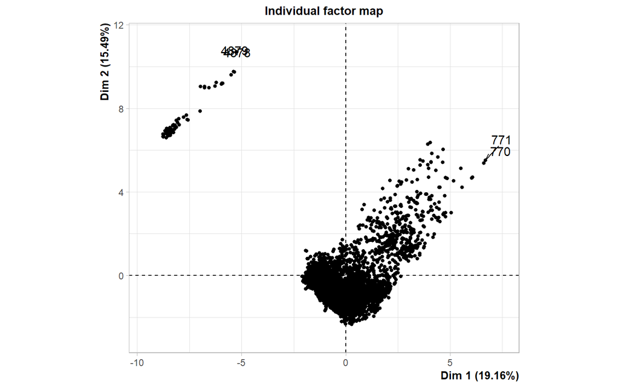

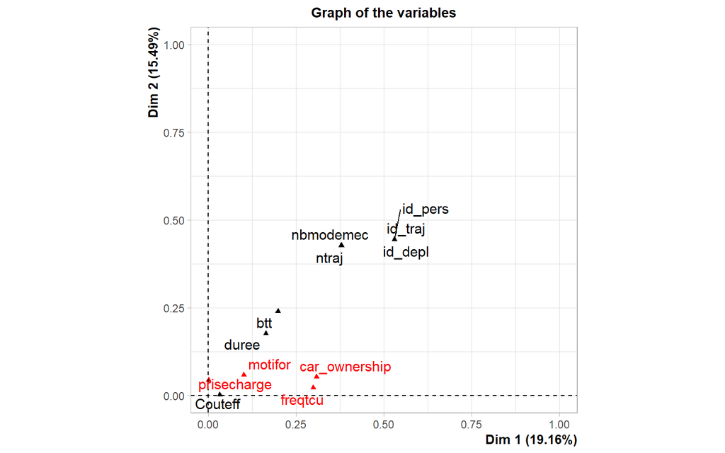

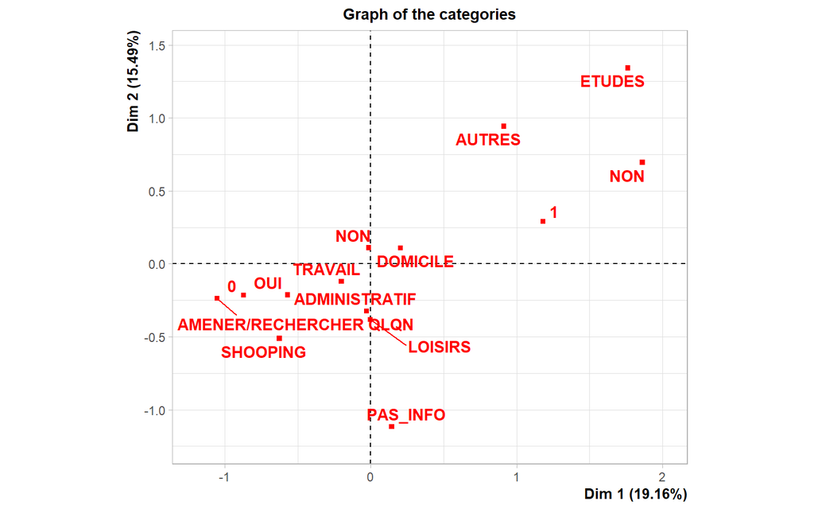

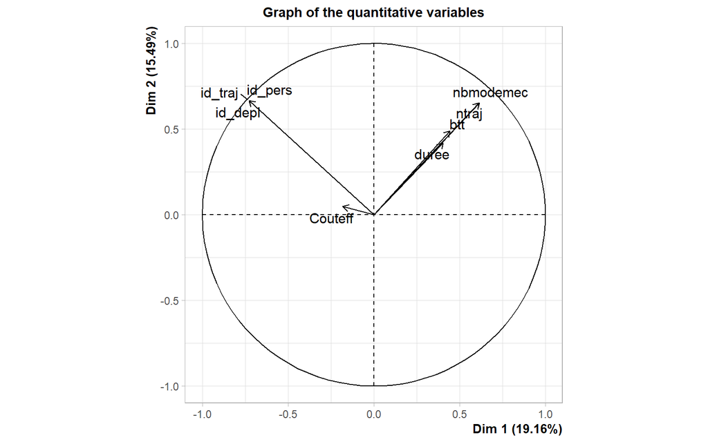

```r
afm_4<-FAMD(DB_trip, ncp=5)
```

```r
#summary(afm_4)
```

```r
#head(afm_4$ind$coord)
```

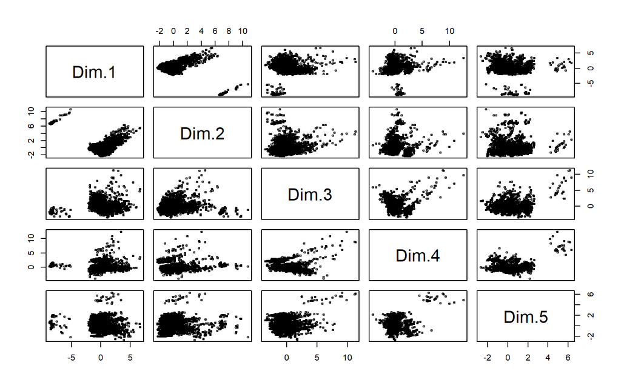

```r
pairs(afm_4$ind$coord,cex=0.5)
```

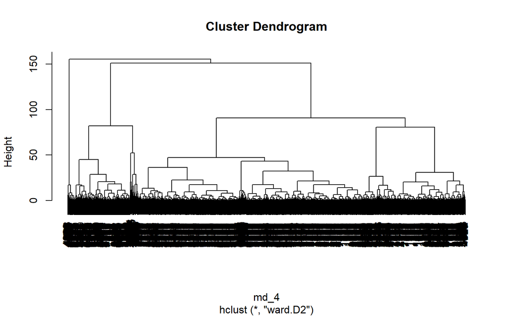

```r
md_4<-dist(afm_4$ind$coord)
ch_4<-hclust(md_4,method="ward.D2")

plot(ch_4)
```

```r
groups_4<-cutree(ch_4,k=3)
#table(groups_4)
```

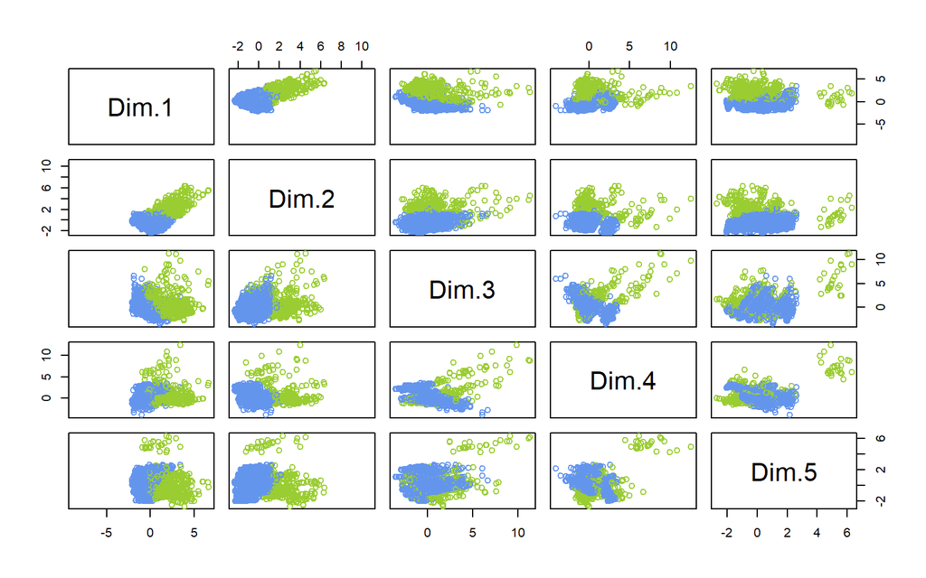

```r
pairs(afm_4$ind$coord,col=c('cornflowerblue','yellowgreen')[groups_4],cew=0.75)
```

```r
#lapply(DB_trip[sapply(DB_trip,is.numeric)],function(x){tapply(x,groups_4,sd)})
#lapply(DB_trip[sapply(DB_trip,is.numeric)],function(x){tapply(x,groups_4,mean)})
#lapply(DB_trip[sapply(DB_trip,is.numeric)],function(x){tapply(x,groups_4,median)})

#lapply(DB_trip[sapply(DB_trip,is.numeric)],function(x){tapply(x,groups_4,var)})
```

```r
#sapply(DB_trip[sapply(DB_trip,is.factor)],function(x){prop.table(table(groups_4,x),1)})
```

En moyenne les temps de trajets sont plus longs avec l’utilisation des transports en communs ( btt_mean c’est à dire le temps passé dans un trajet quotidiennement qui vaut 268 minutes, dans le deuxième groupe contre 96 minutes dans le premier) ou bien duree qui est en moyene de 57 minutes contre 17 minutes dans le premier groupe.Il faudrait néanmmoins voir ce que nous disent le groupe travaillant sur les heures de pointes car il y a peut être un rapport différent durant ces horraires là.

Le motif de déplacement est assez similaire lorsqu’il s’agit de se rendre au travail, il n’y a pas de différence notoire, cependant, lorsqu’il s’agit de déposer une personne , l’usage des transports en communs n’est pas privilégié.

Toujours en lien avec notre variable (W) car_ownership, le fait d’avoir à disposition un véhicule favorise grandement son utilisation au détriment des TC , les trajets du premier groupe sont effectués avec 90% des personnes qui ont à disposition un véhicule contre 1 personne sur deux pour le deuxième groupe.

# Modèles de prédiction

Avec ce qu’on a pu voir et l’importance de car_ownership , nous allons tenter de modéliser notre variable de “Confort_social” via plusieurs autres variables selon leurs valeurs. Le choix de ces variables a été fait via l’Analyse des Composants Multiples et nos clutering effectués.

```r
library(caret)
library(ROCR)
```

```r
DB_test_model_2<-DB_pers_socio_1%>%
  mutate(Confort_social=case_when(DB_pers_socio_1$csp %in%c("HIGH_STATUT")&DB_pers_socio_1$ABO_TC %in% c("OUI_GRATUIT","OUI_PAYANT") & DB_pers_socio_1$zonetrav %in% c("CENTRE_VILLE") &DB_pers_socio_1$car_ownership %in%c("OUI") ~ 1,
              DB_pers_socio_1$csp %in% c("HIGH_STATUT")   & DB_pers_socio_1$zonetrav %in% c("CENTRE_VILLE","AGGLO_PROCHE") & DB_pers_socio_1$car_ownership %in% c("NON")& ABO_TC %in% c("OUI_GRATUIT","OUI_PAYANT","NON") ~2,



                TRUE~3))
```

## Régression Logistique

```r
splitIndex_2=createDataPartition(DB_test_model_2$freqtcu, p = 0.8, list = FALSE, times = 1)
train_2=DB_test_model_2[ splitIndex_2,]
test_2=DB_test_model_2[-splitIndex_2,]
model_glm_test_2 =glm(formula = freqtcu ~ tailmng + Confort_social, data = train_2, family = "binomial")

summary(model_glm_test_2)
```

```
##
## Call:
## glm(formula = freqtcu ~ tailmng + Confort_social, family = "binomial",
##     data = train_2)
##
## Coefficients:
##                Estimate Std. Error z value Pr(>|z|)
## (Intercept)     1.60819    0.42344   3.798 0.000146 ***
## tailmng         0.26415    0.07791   3.391 0.000697 ***
## Confort_social -0.78095    0.14090  -5.543 2.98e-08 ***
## ---
## Signif. codes:  0 '***' 0.001 '**' 0.01 '*' 0.05 '.' 0.1 ' ' 1
##
## (Dispersion parameter for binomial family taken to be 1)
##
##     Null deviance: 1722.9  on 1251  degrees of freedom
## Residual deviance: 1676.9  on 1249  degrees of freedom
## AIC: 1682.9
##
## Number of Fisher Scoring iterations: 4
```

```r
predictions_2 <- predict(model_glm_test_2, newdata = test_2, type = "response")
pred_class_2<-factor(ifelse(predictions_2>0.5,1,0))
```

```r
confusionMatrix(pred_class_2,test_2$freqtcu)
```

```
## Confusion Matrix and Statistics
##
##           Reference
## Prediction   0   1
##          0 150 103
##          1  22  37
##
##                Accuracy : 0.5994
##                  95% CI : (0.5427, 0.6542)
##     No Information Rate : 0.5513
##     P-Value [Acc > NIR] : 0.049
##
##                   Kappa : 0.1441
##
##  Mcnemar's Test P-Value : 8.342e-13
##
##             Sensitivity : 0.8721
##             Specificity : 0.2643
##          Pos Pred Value : 0.5929
##          Neg Pred Value : 0.6271
##              Prevalence : 0.5513
##          Detection Rate : 0.4808
##    Detection Prevalence : 0.8109
##       Balanced Accuracy : 0.5682
##
##        'Positive' Class : 0
##
```

## Classificateur naif bayesienn

Un deuxième modèle de classification connu qui peut nous être utile , le classificateur naif bayesienn

```r
library(e1071)
set.seed(234)
# Split the data into training and test sets
splitIndex_B = createDataPartition(DB_test_model_2$freqtcu, p = 0.8, list = FALSE, times = 1)
train_B = DB_test_model_2[ splitIndex_B,]
test_B = DB_test_model_2[-splitIndex_B,]
# Train the SVM classifier
naiv_1 = naiveBayes(freqtcu ~ tailmng+permis+Confort_social, data = train_B)
# Make predictions on the test set
predictions_B = predict(naiv_1, test_B)
confusionMatrix(predictions_B, test_B$freqtcu)
```

```
## Confusion Matrix and Statistics
##
##           Reference
## Prediction   0   1
##          0 153 111
##          1  19  29
##
##                Accuracy : 0.5833
##                  95% CI : (0.5265, 0.6386)
##     No Information Rate : 0.5513
##     P-Value [Acc > NIR] : 0.1397
##
##                   Kappa : 0.103
##
##  Mcnemar's Test P-Value : 1.449e-15
##
##             Sensitivity : 0.8895
##             Specificity : 0.2071
##          Pos Pred Value : 0.5795
##          Neg Pred Value : 0.6042
##              Prevalence : 0.5513
##          Detection Rate : 0.4904
##    Detection Prevalence : 0.8462
##       Balanced Accuracy : 0.5483
##
##        'Positive' Class : 0
##
```

# Annexes

## Bibliographie

| # | Authors | Year | Title | Source |
| --- | --- | --- | --- | --- |
| 1 | Paulley, N., Balcombe, R., Mackett, R., Titheridge, H., Preston, J., Wardman, M., … & White, P. | 2006 | The demand for public transport: The effects of fares, quality of service, income and car ownership. | Transport policy, 13(4), 295-306. |
| 2 | Redman, L., Friman, M., Gärling, T., & Hartig, T. | 2013 | Quality attributes of public transport that attract car users: A research review. | Transport policy, 25, 119-127. |
| 3 | Zhang, Wang, M., Dong, J., Lu, W., Liu, Y., Ni, A., & Yu, X. | 2022 | Factors and Mechanism Affecting the Attractiveness of Public Transport: Macroscopic and Microscopic Perspectives. | Journal of Advanced Transportation, 2022, 1–16. |
| 4 | Raşca, & Saeed, N. | 2022 | Exploring the factors influencing the use of public transport by commuters living in networks of small cities and towns. | Travel, Behaviour & Society, 28, 249–263. |
| 5 | Göransson, & Andersson, H. | 2023 | Factors that make public transport systems attractive: a review of travel preferences and travel mode choices. | European Transport Research Review, 15(1), 32–14. |

## Listes variables à plus de 80% de valeurs manquantes

- motoracc
- situveil
- STAT_TRAV
- TYPE_STAT4
- LIEU_STAT4
- POSSES4
- PUIS_VP4
- AN_VP4
- ENERGIE4
- GENRE4
- TYPE_STAT3
- LIEU_STAT3
- POSSES3
- PUIS_VP3
- AN_VP3
- ENERGIE3
- motdeacc
- nbarret
- abonpeage